# Functions for Figures

## Writing functions to generate figures

Now that we have functions to generate the datasets we need for our paper, we can start using them to generate the figures.

To illustrate this concept, we are going to generate a figure before converting it into a function.

First, load needed libraries and load data from a GeoTIFF raster file.

```r
library("raster")

# Change to appropriate path as needed
teak_chm_f <- "TEAK_lidarCHM.tif"
teak_chm <- raster(teak_chm_f)
```

## Plotting a density function for canopy heights

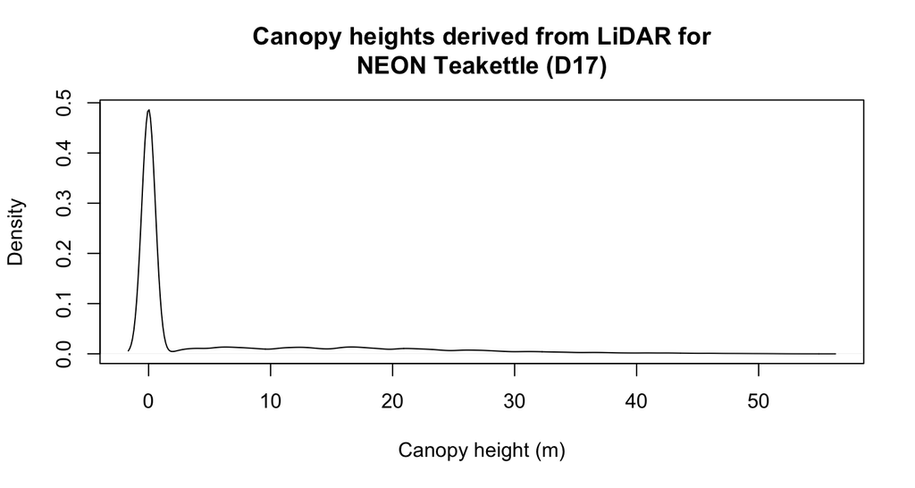

```r
# plot pd function for canopy heights
density(teak_chm, main = "Canopy heights derived from LiDAR for\nNEON Teakettle (D17)",
        xlab = "Canopy height (m)")
```

## Some light data cleaning

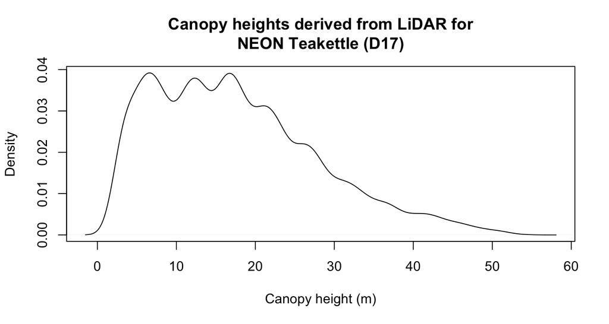

```r
# Set 0 values to NA (ground values)
teak_chm[teak_chm == 0] <- NA

density(teak_chm, main = "Canopy heights derived from LiDAR for\nNEON Teakettle (D17)",
     xlab = "Canopy height (m)")
```

## Writing to PDF

If we want to make a PDF file of this figure we could do:

```r
pdf(file="teak_chm_density.pdf", width=8, height=6)

density(teak_chm, main = "Canopy heights derived from LiDAR for\nNEON Teakettle (D17)",
     xlab = "Canopy height (m)")

dev.off()
```

## Shortcomings

This example is relatively simple but if you are building a more complex figure that relies on several variables, it means that they will be globally available in your knitr document, potentially causing conflicts down the road.

## Improvements

Let's convert this into a function:

```r
# expects a chm raster dataset and a character string
density_plot_from_chm <- function(chm, title) {
    density(chm, main = title, xlab = "Canopy height (m)")
}
```

## Prettier

So this part gets a little prettier:

```r
pdf(file="teak_chm_density.pdf", width=8, height=6)

density_plot_from_chm(teak_chm, "Canopy heights derived from LiDAR for\n
                                NEON Teakettle (D17)")

dev.off()
```

If you start making a lot of figures, it would be nice to have to repeat this first and third lines…

## Automated

Let's create another function that will automate this process:

```r
## An example that generates a PDF file from a function that creates a plot
## See http://nicercode.github.io/blog/2013-07-09-figure-functions/
make_pdf <- function(expr, filename, ..., verbose = TRUE) {
    if (verbose) {
        message("Creating: ", filename)
    }
    pdf(file = filename, ...)
    on.exit(dev.off())
    eval.parent(substitute(expr))
}
```

```r
make_pdf(density_plot_from_chm(teak_chm,
                               title = "Canopy heights for NEON Teakettle"),
         filename = "teak_chm_density.pdf", width = 8, height = 6)
```

```
## Creating: teak_chm_density.pdf
```

## Further improvements

We can even improve our `density_plot_from_chm` function to make it a little more general. For instance, we can add an argument to add vertical line breaks at arbitrary positions.

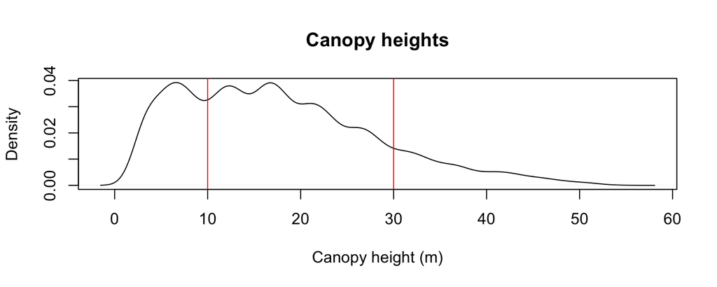

```r
# expects a raster, character string, and numeric vector for vertical breaks
density_plot_from_chm <- function(chm, title, breaks) {
    density(chm, main = title, xlab = "Canopy height (m)")
    sapply(breaks, function(x) abline(v = x, col = "red"))
}

density_plot_from_chm(teak_chm, title = "Canopy heights", breaks = c(10,30))
```

## Your turn

```r
# create a function to generate a histogram from a CHM raster and use it with make_pdf

make_pdf <- function(expr, filename, ..., verbose = TRUE) {
    if (verbose) {
        message("Creating: ", filename)
    }
    pdf(file = filename, ...)
    on.exit(dev.off())
    eval.parent(substitute(expr))
}

# expects a raster, character string, and numeric vector for vertical breaks
density_plot_from_chm <- function(chm, title, breaks) {
    density(chm, main = title, xlab = "Canopy height (m)")
    sapply(breaks, function(x) abline(v = x, col = "red"))
}
```